# Spatio-temporal Modelling, Lab 5, 2022-11-30

# 3 Spatial prediction with multiple linear regression

In the data set `meuse` we have a large number of variables present that can be used to form predictive regression models for either of the heavy metal variables. If we want to use such a regression model for spatial prediction, we need the variables as a full spatial coverage, e.g. in the form of a regular grid covering the study area, as well.

Only few variables are available for this in `meuse.grid`. Let´s reload the original data set:

**sp**

```r
meuse.grid <- as(readGDAL("./data/meuse_grid.tif"),"SpatialPixelsDataFrame") #reload original data set
```

```
./data/meuse_grid.tif has GDAL driver GTiff
and has 104 rows and 78 columns
```

```r
names(meuse.grid) <- c("part.a","part.b","dist","soil","ffreq")
meuse.grid$soil <- as.factor(meuse.grid$soil)
meuse.grid$ffreq <- as.factor(meuse.grid$ffreq)
names(meuse.grid)
```

```
[1] "part.a" "part.b" "dist"   "soil"   "ffreq"
```

**sf/stars**

```r
meuse.grid.stars <- read_stars("./data/meuse_grid.tif") #reload original data set
meuse.grid.stars <- split(meuse.grid.stars, "band")
names(meuse.grid.stars) <- c("part.a","part.b","dist","soil","ffreq")
meuse.grid.stars$soil <- as.factor(meuse.grid.stars$soil)
meuse.grid.stars$ffreq <- as.factor(meuse.grid.stars$ffreq)
names(meuse.grid.stars)
```

```
[1] "part.a" "part.b" "dist"   "soil"   "ffreq"
```

We already demonstrated using `dist` at the beginning of this exercise and we saw that some assumptions underlying linear regression were violated. Often, simple transformations of the input data can help, e.g., to overcome non-linearity or heteroscedastic residuals. Try:

**sp**

```r
lzn.lm = lm(log(zinc) ~ sqrt(dist), meuse)
summary(lzn.lm)
```

```
Call:
lm(formula = log(zinc) ~ sqrt(dist), data = meuse)

Residuals:
     Min       1Q   Median       3Q      Max
-1.04624 -0.29060 -0.01869  0.26445  1.59685

Coefficients:
            Estimate Std. Error t value Pr(>|t|)
(Intercept)  6.99438    0.07593   92.12   <2e-16 ***
sqrt(dist)  -2.54920    0.15498  -16.45   <2e-16 ***
---
Signif. codes:  0 '***' 0.001 '**' 0.01 '*' 0.05 '.' 0.1 ' ' 1

Residual standard error: 0.4353 on 153 degrees of freedom
Multiple R-squared:  0.6388,    Adjusted R-squared:  0.6364
F-statistic: 270.6 on 1 and 153 DF,  p-value: < 2.2e-16
```

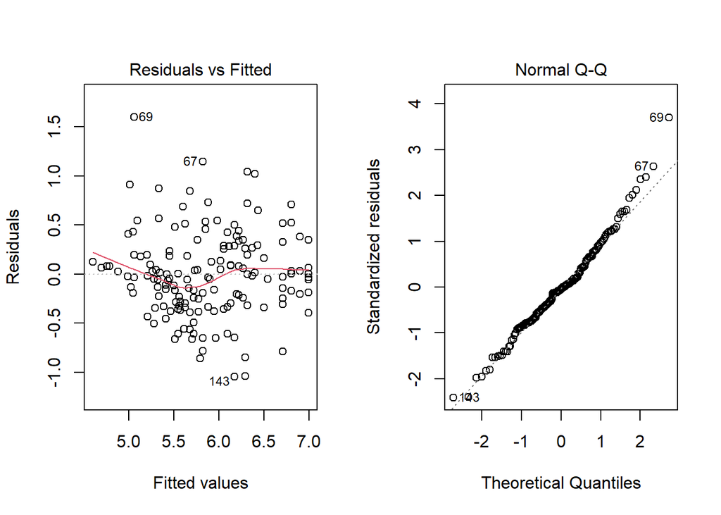

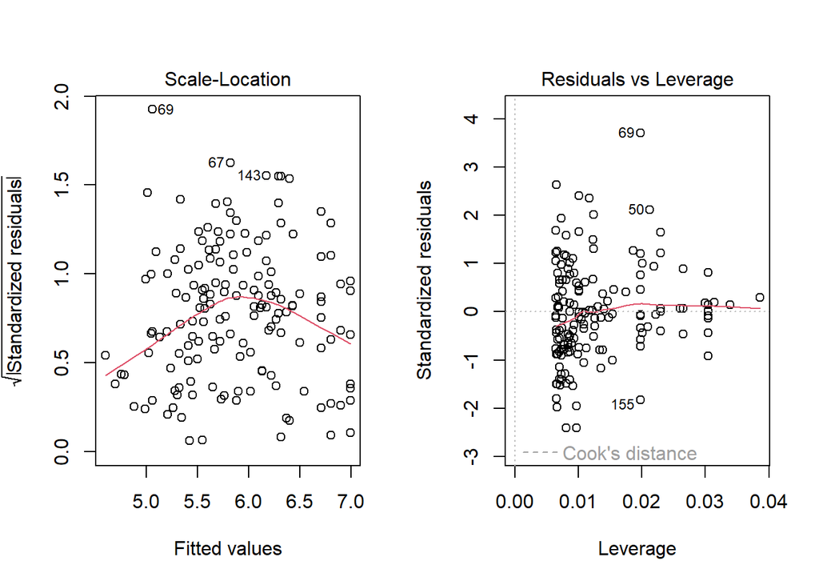

```r
par(mfrow=c(1,2))
plot(lzn.lm)
```

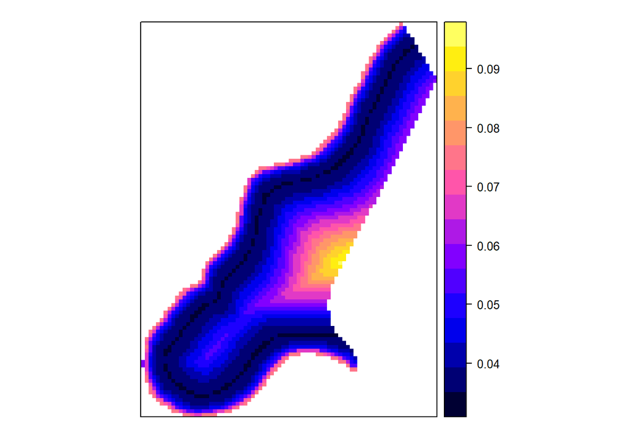

```r
plot(log(zinc) ~ sqrt(dist), meuse)
abline(lzn.lm)


lzn.pr = predict(lm(log(zinc) ~ sqrt(dist), meuse), meuse.grid, se.fit = TRUE)
meuse.grid$lzn.fit = lzn.pr$fit
spplot(meuse.grid, "lzn.fit")

meuse.grid$se.fit = lzn.pr$se.fit
spplot(meuse.grid, "se.fit")
```

**sf/stars**

```r
lzn.lm = lm(log(zinc) ~ sqrt(dist), meuse.sf)
summary(lzn.lm)
```

```
Call:
lm(formula = log(zinc) ~ sqrt(dist), data = meuse.sf)

Residuals:
     Min       1Q   Median       3Q      Max
-1.04624 -0.29060 -0.01869  0.26445  1.59685

Coefficients:
            Estimate Std. Error t value Pr(>|t|)
(Intercept)  6.99438    0.07593   92.12   <2e-16 ***
sqrt(dist)  -2.54920    0.15498  -16.45   <2e-16 ***
---
Signif. codes:  0 '***' 0.001 '**' 0.01 '*' 0.05 '.' 0.1 ' ' 1

Residual standard error: 0.4353 on 153 degrees of freedom
Multiple R-squared:  0.6388,    Adjusted R-squared:  0.6364
F-statistic: 270.6 on 1 and 153 DF,  p-value: < 2.2e-16
```

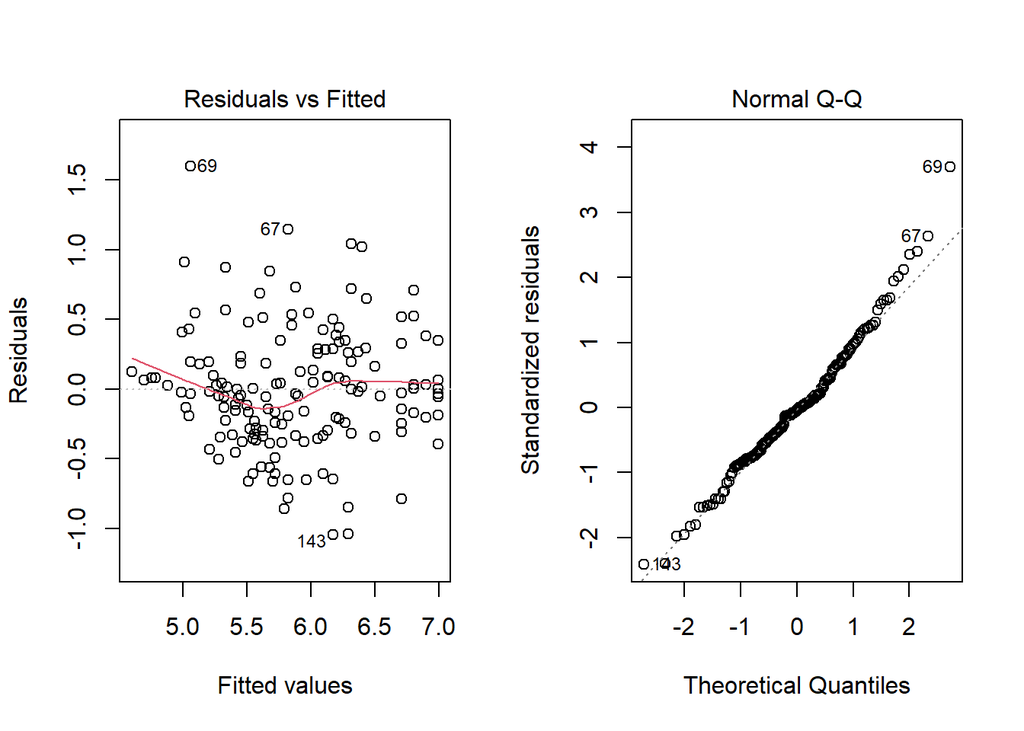

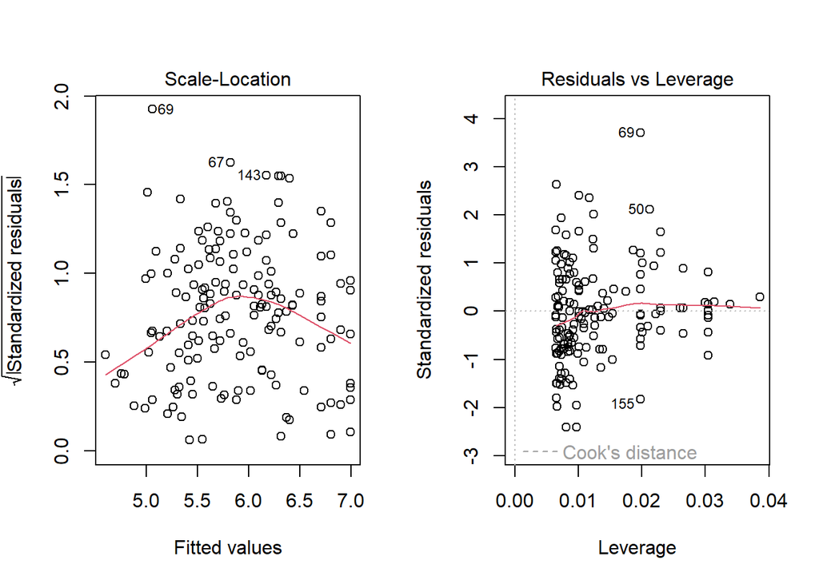

```r
par(mfrow=c(1,2))
plot(lzn.lm)
```

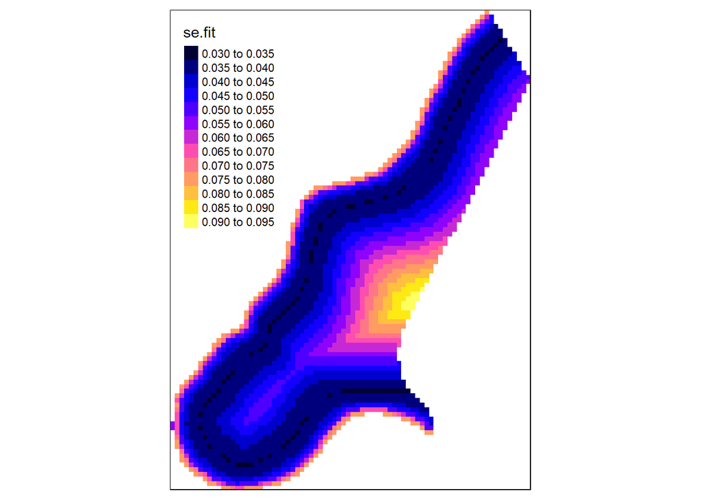

```r
plot(log(zinc) ~ sqrt(dist), meuse.sf)
abline(lzn.lm)


lzn.pr = predict(lm(log(zinc) ~ sqrt(dist), meuse.sf), meuse.grid.stars, se.fit = TRUE)
meuse.grid.stars$lzn.fit = lzn.pr$fit


tm_shape(meuse.grid.stars)+tm_raster("lzn.fit",n=10, palette = bpy.palette)
meuse.grid.stars$se.fit = lzn.pr$se.fit
tm_shape(meuse.grid.stars)+tm_raster("se.fit", n=10, palette = bpy.palette)
```

#### *Exercise 4*

**Exercise 4**

*Why are prediction standard errors on the log-scale largest for small and large distance to the river?*

1. Because variability is smallest for intermediate distance to river
2. because the uncertainty in the regression slope is most prevalent when the regressor *distance* takes extreme values
3. because we have too few degrees of freedom for regression (i.e., too few observations) overall
4. because we have too little data close to the river and far away from the river

**Solution**

The correct answer is b). The uncertainty introduced by the slope of the regression model is highest for low and high distance values.

We can use the prediction errors provided by `lm` to calculate regression prediction intervals:

**sp**

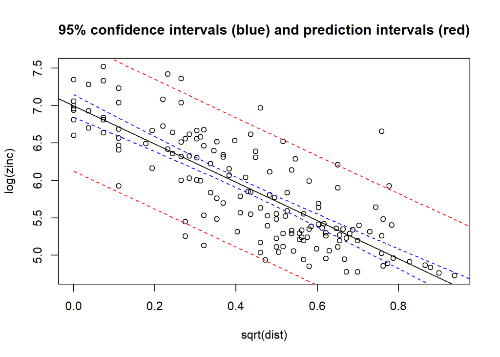

```r
plot(log(zinc) ~ sqrt(dist), meuse)
x = 0:100/100
lzn.lm = lm(log(zinc) ~ sqrt(dist), meuse)
pr = predict(lzn.lm, data.frame(dist = x), interval = "prediction")
abline(lzn.lm)
lines(sqrt(x), pr[, 2], lty = "dashed", col = "red")
lines(sqrt(x), pr[, 3], lty = "dashed", col = "red")
pr = predict(lzn.lm, data.frame(dist = x), interval = "confidence")
lines(sqrt(x), pr[, 2], lty = "dashed", col = "blue")
lines(sqrt(x), pr[, 3], lty = "dashed", col = "blue")
title("95% confidence intervals (blue) and prediction intervals (red)")
```

**sf/stars**

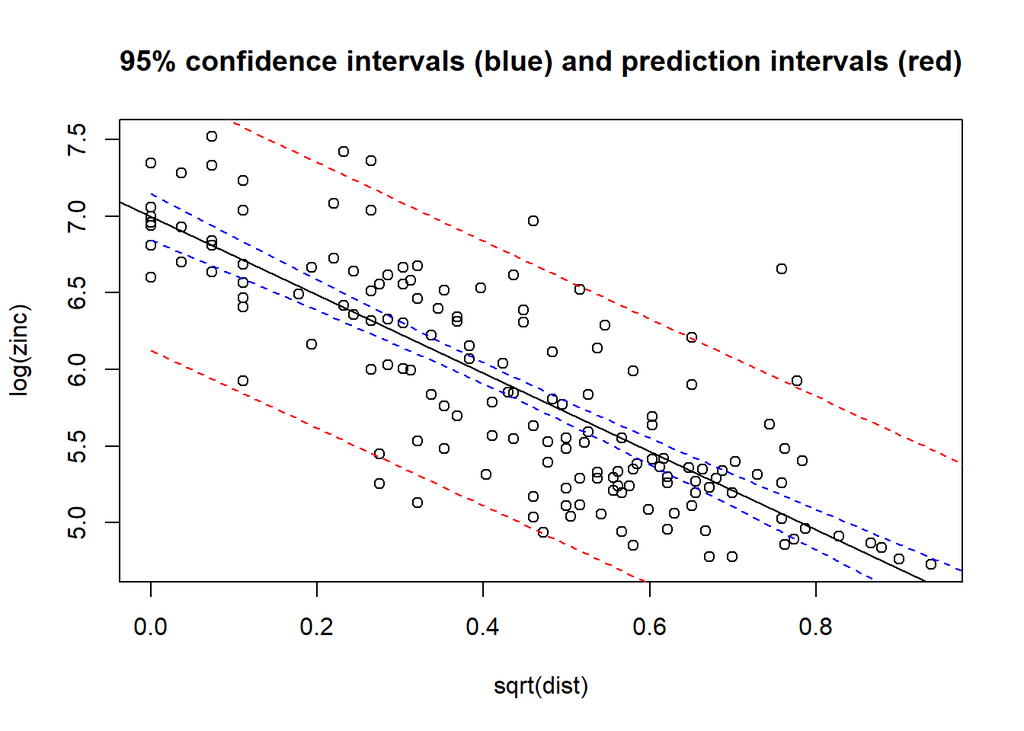

```r
plot(log(zinc) ~ sqrt(dist), meuse.sf)
x = 0:100/100
lzn.lm = lm(log(zinc) ~ sqrt(dist), meuse.sf)
pr = predict(lzn.lm, data.frame(dist = x), interval = "prediction")
abline(lzn.lm)
lines(sqrt(x), pr[, 2], lty = "dashed", col = "red")
lines(sqrt(x), pr[, 3], lty = "dashed", col = "red")
pr = predict(lzn.lm, data.frame(dist = x), interval = "confidence")
lines(sqrt(x), pr[, 2], lty = "dashed", col = "blue")
lines(sqrt(x), pr[, 3], lty = "dashed", col = "blue")
title("95% confidence intervals (blue) and prediction intervals (red)")
```

Next, we can make maps of the 95% prediction intervals:

**sp**

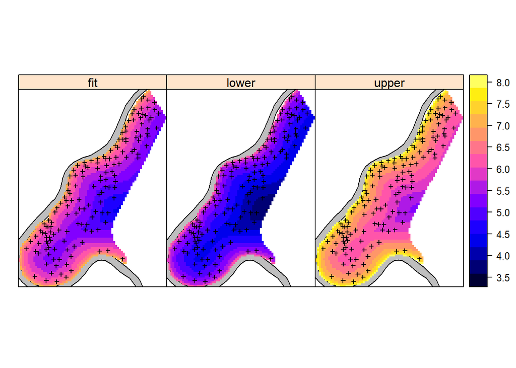

```r
pr = predict(lzn.lm, as.data.frame(meuse.grid), interval = "prediction")
meuse.grid$fit = pr[, 1]
meuse.grid$upper = pr[, 3]
meuse.grid$lower = pr[, 2]
spplot(meuse.grid, c("fit", "lower", "upper"), sp.layout = meuse.lt, layout = c(3,
    1))
```

**sf/stars**

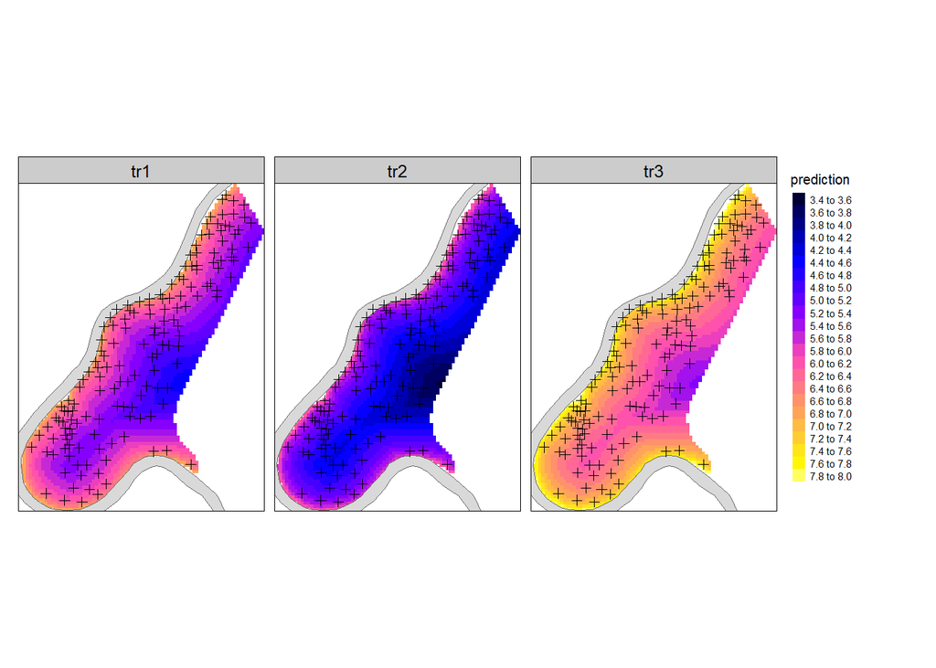

```r
pr = predict(lzn.lm, as.data.frame(meuse.grid.stars), interval = "prediction")
meuse.grid.stars$fit = pr[, 1]
meuse.grid.stars$upper = pr[, 3]
meuse.grid.stars$lower = pr[, 2]
tm_shape(meuse.grid.stars) +
  tm_raster(c("fit","lower","upper"),n=20,title = "prediction", palette = bpy.palette) +
  tm_shape(meuse.riv.sf)+tm_polygons() +
  tm_shape(meuse)+tm_symbols(shape = 3,size = 0.2,col="black") +
  tm_facets(ncol = 3,nrow=1,free.scales = FALSE) +
  tm_layout(legend.outside.size = 0.15, panel.labels = c("tr1","tr2","tr3"))
```

Note that all these prediction intervals refer to prediction of single observations; confidence intervals for mean values (i.e., the regression line alone) are obtained by specifying interval = `"confidence"`.

#### *Exercise 5*

**Exercise 5**

*Compared to prediction intervals, the intervals obtained by interval = `"confidence"` are*

1. wider
2. narrower
3. of approximately equal width

**Solution**

The correct answer is b). The confidence intervals for **single observations** (prediction intervals) are wider than intervals obtained by `interval = confidence"` because the latter are for the regression line, i.e. confidence intervals of the **mean** for a certain distance.

Another regression model is obtained by relating zinc to flood frequency, try

**sp**

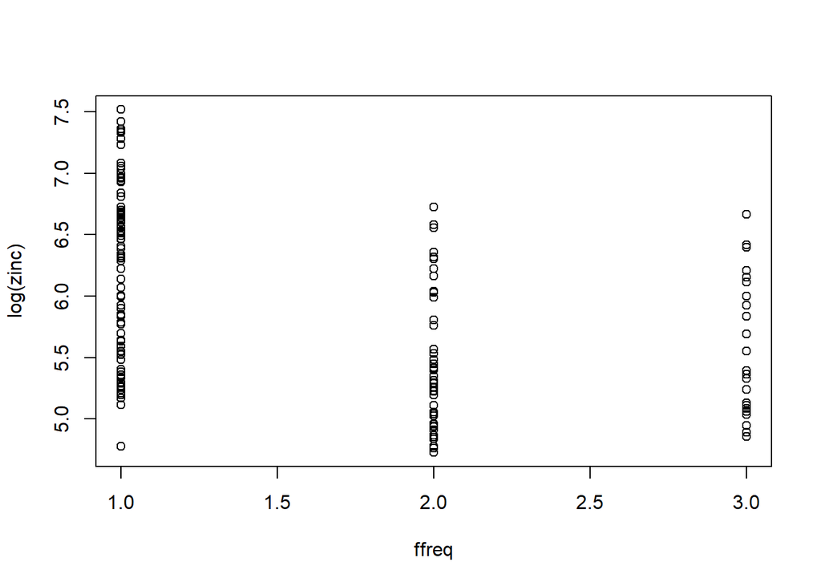

```r
plot(log(zinc) ~ ffreq, meuse)
```

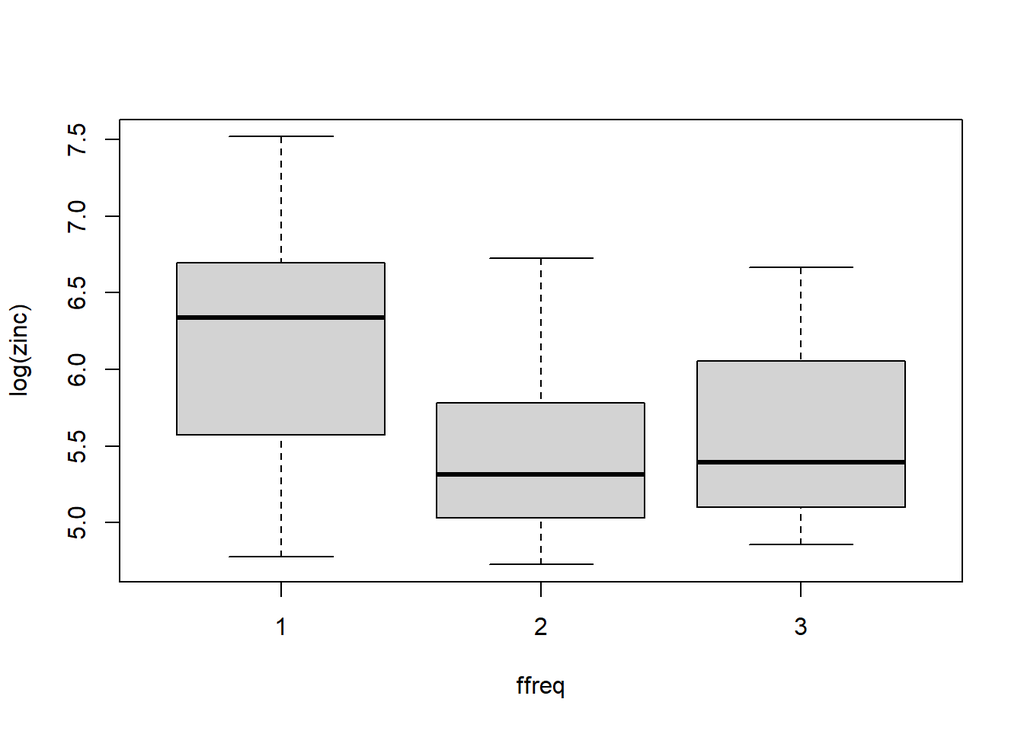

```r
meuse$ffreq <- as.factor(meuse$ffreq)
plot(log(zinc) ~ ffreq, meuse)
```

**sf/stars**

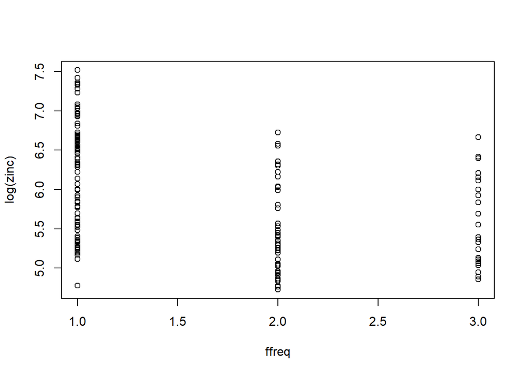

```r
plot(log(zinc) ~ ffreq, meuse.sf)
```

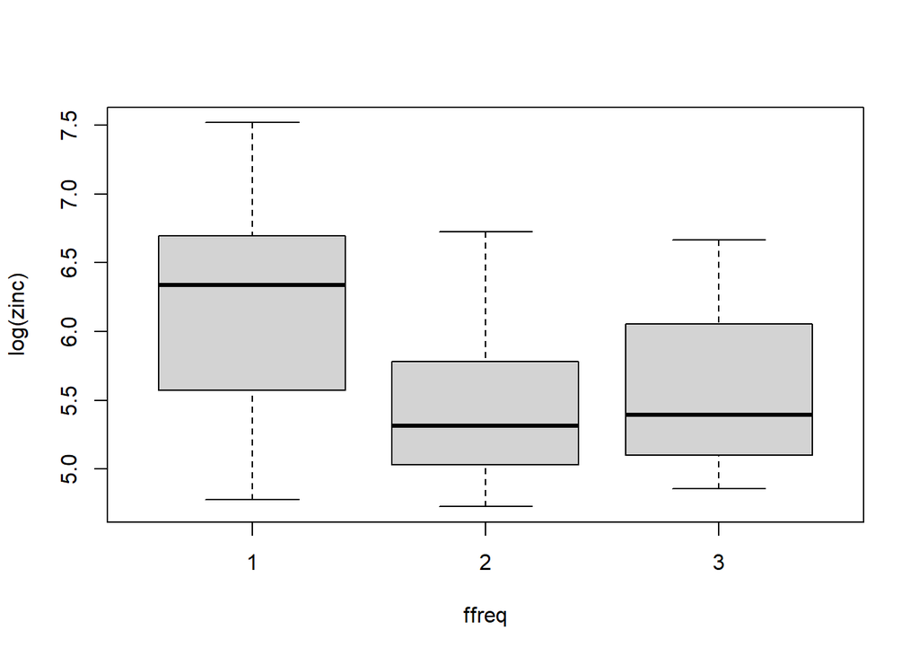

```r
meuse.sf$ffreq <- as.factor(meuse.sf$ffreq)
plot(log(zinc) ~ ffreq, meuse.sf)
```

#### *Exercise 6*

**Exercise 6**

*Why is a box-and whisker plot drawn for the second plot, and not a scatter plot?*

1. `ffreq` has been turned into a categorical variable with numeric levels
2. `ffreq` has been turned into a variable with only three values, 1, 2 and 3
3. flood frequency is always expressed by boxes

**Solution**

The correct answer is a). Flood frequency in our data set has numbers as labels, but can actually be seen as a categorical variable with the number of floodings being the categories. By using `as.factor()` we explicitly turn this variable into a factor, R´s representation of categorical variables. When plotting such a variable, a more meaningful representation (box plots) is automatically used.

#### *Exercise 7*

**Exercise 7**

*What do the boxes in a box-and whisker plot refer to?*

1. the mean plus and minus one standard deviation of the group
2. the 95 percent confidence interval for the mean
3. the inter-quartile range (from 25-th to 75-th percentiles)

**Solution**

The correct answer is c).

#### *Exercise 8*

**Exercise 8**

*What is needed for flood frequency to use it for mapping zinc?*

1. it needs to be the number of times a grid cell floods
2. it needs to be known at each prediction location (i.e., grid cells in `meuse.grid`)
3. it needs to be independent of distance to the river

**Solution**

The correct answer is b).

Try the model in prediction mode:

**sp**

```r
lzn.lm2 = lm(log(zinc) ~ ffreq, meuse)
summary(lzn.lm2)
```

```
Call:
lm(formula = log(zinc) ~ ffreq, data = meuse)

Residuals:
     Min       1Q   Median       3Q      Max
-1.43726 -0.51417 -0.04058  0.46446  1.30060

Coefficients:
            Estimate Std. Error t value Pr(>|t|)
(Intercept)  6.21638    0.06852  90.727  < 2e-16 ***
ffreq2      -0.76415    0.11362  -6.725 3.34e-10 ***
ffreq3      -0.63323    0.14778  -4.285 3.23e-05 ***
---
Signif. codes:  0 '***' 0.001 '**' 0.01 '*' 0.05 '.' 0.1 ' ' 1

Residual standard error: 0.628 on 152 degrees of freedom
Multiple R-squared:  0.2531,    Adjusted R-squared:  0.2433
F-statistic: 25.75 on 2 and 152 DF,  p-value: 2.338e-10
```

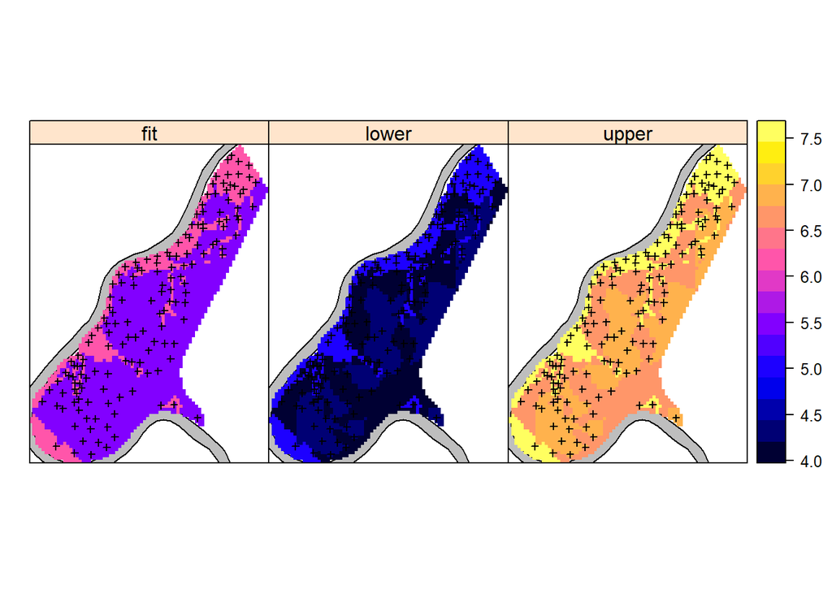

```r
pr = predict(lzn.lm2, meuse.grid, interval = "prediction")
meuse.grid$fit = pr[, 1]
meuse.grid$upper = pr[, 3]
meuse.grid$lower = pr[, 2]
spplot(meuse.grid, c("fit", "lower", "upper"), sp.layout = meuse.lt, layout = c(3,1))
```

**sf/stars**

```r
lzn.lm2 = lm(log(zinc) ~ ffreq, meuse.sf)
summary(lzn.lm2)
```

```
Call:
lm(formula = log(zinc) ~ ffreq, data = meuse.sf)

Residuals:
     Min       1Q   Median       3Q      Max
-1.43726 -0.51417 -0.04058  0.46446  1.30060

Coefficients:
            Estimate Std. Error t value Pr(>|t|)
(Intercept)  6.21638    0.06852  90.727  < 2e-16 ***
ffreq2      -0.76415    0.11362  -6.725 3.34e-10 ***
ffreq3      -0.63323    0.14778  -4.285 3.23e-05 ***
---
Signif. codes:  0 '***' 0.001 '**' 0.01 '*' 0.05 '.' 0.1 ' ' 1

Residual standard error: 0.628 on 152 degrees of freedom
Multiple R-squared:  0.2531,    Adjusted R-squared:  0.2433
F-statistic: 25.75 on 2 and 152 DF,  p-value: 2.338e-10
```

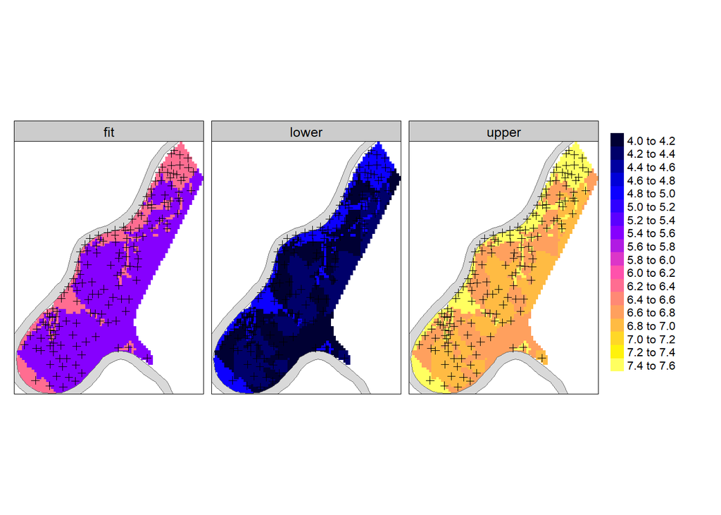

```r
pr = predict(lzn.lm2, meuse.grid.stars, interval = "prediction")
meuse.grid.stars$fit = pr[, 1]
meuse.grid.stars$upper = pr[, 3]
meuse.grid.stars$lower = pr[, 2]
tm_shape(meuse.grid.stars) +
  tm_raster(c("fit", "lower", "upper"), palette = bpy.palette, title = "", n=20) +
  tm_shape(meuse.riv)+tm_polygons() +
  tm_shape(meuse.sf) +
  tm_symbols(size = 0.2,shape = 3,col = "black") +
  tm_facets(free.scales = FALSE) +
  tm_layout(legend.outside.size = 0.15, panel.labels = c("fit","lower","upper"))
```

#### *Exercise 9*

**Exercise 9**

*Why is the pattern obtained not smooth?*

**Solution**

ffreq is a categorical variable so there are leaps in the map where the flood frequency changes.

## References

Burrough, P. A., and R. A. McDonnell. 1998. *Principles of Geographical Information Systems*. Oxford University Press.

Pebesma, Edzer. 2004. “Multivariable Geostatistics in S: The Gstat Package.” *Computers & Geosciences* 30: 683–91.

———. 2022a. *Sf: Simple Features for r*. https://CRAN.R-project.org/package=sf.

———. 2022b. *Stars: Spatiotemporal Arrays, Raster and Vector Data Cubes*. https://CRAN.R-project.org/package=stars.

Pebesma, Edzer, and Roger Bivand. 2022a. *Sp: Classes and Methods for Spatial Data*. https://CRAN.R-project.org/package=sp.

———. 2022b. *Spatial Data Science, with Applications in R*. online. https://r-spatial.org/book/.

Pebesma, Edzer, and Benedikt Graeler. 2022. *Gstat: Spatial and Spatio-Temporal Geostatistical Modelling, Prediction and Simulation*. https://github.com/r-spatial/gstat/.

Rikken, M. G. J., and RPG Van Rijn. 1993. *Soil Pollution with Heavy Metals - an Inquiry into Spatial Variation, Cost of Mapping and the Risk Evaluation of Copper, Cadmium, Lead and Zinc in the Floodplains of the Meuse West of Stein, the Netherlands. Doctoraalveldwerkverslag*. Dept. of Physical Geography, Utrecht University.

Tennekes, Martijn. 2022. *Tmap: Thematic Maps*. https://github.com/r-tmap/tmap.